# Tutorial for Creating Annotated SVGs

# 5 Formatting the Data

When plotting SHMs, only spatial features that have common identifiers between the aSVG and assay data are colored. As a result, it’s crucial to format the assay data. The supported data containers include `vector`, `data frame`, and `SummarizedExperiment` (SE) (Morgan et al. 2018). This section focuses on `SE`. Details of the other two data containers are provided in the *spatialHeatmap* [vignette](https://bioconductor.org/packages/devel/bioc/vignettes/spatialHeatmap/inst/doc/spatialHeatmap.html#61_Numeric_Data).

For plotting SHMs, the two most important slots in `SE` are `assay` and `colData`. The `assay` slot stores the numeric data matrix, where rows and columns are biomolecules (e.g. genes) and samples respectively, while the `colData` slot stores experimental design information such as replicates and treatments. Formatting `SE` objects is essentially editing information in the `colData` slot.

The experimental design information can be imported to the `colData` slot from a tabular targets file. The target file should meet the following requirements:

1. It contains at least two columns. One column represents spatial features (`spFeature`) and the other one experimental variables (`variable`) such as treatments. The rows in the target file correspond to the columns of the numeric data stored in the `assay` slot.
2. To be colored in SHMs, the spatial features must have common identifiers between the assay data and aSVG. Note, the double underscore is a special string reserved for specific purposes in *spatialHeatmap*, and thus should be avoided for naming spatial features and variables.

The following example illustrates the design of a valid `SummarizedExperiment` object for generating SHMs. In this example, “root_pGL2” (root atrichoblast epidermis) has 2 experiment variables (“control” and “hypoxia”) and each has 2 replicates. Thus, there are 4 assays for “root_pGL2”. The same design applies to `root_pCO2` (root cortex). These information is stored in a targets file `target.test`.

```r
spft <- c(rep('root_pGL2', 4), rep('root_pCO2', 4))
vars <- rep(c('control', 'control', 'hypoxia', 'hypoxia'), 2)
target.test <- data.frame(spFeature=spft, variable=vars, row.names=paste0('assay', 1:8))
target.test
```

```
##        spFeature variable
## assay1 root_pGL2  control
## assay2 root_pGL2  control
## assay3 root_pGL2  hypoxia
## assay4 root_pGL2  hypoxia
## assay5 root_pCO2  control
## assay6 root_pCO2  control
## assay7 root_pCO2  hypoxia
## assay8 root_pCO2  hypoxia
```

The `assay` slot is populated with a `data.frame` containing random numbers. Each column corresponds to an assay in the target file, while each row corresponds to a gene.

```r
set.seed(10)
df.se <- data.frame(matrix(sample(x=1:1000, size=160), nrow=20))
rownames(df.se) <- paste0('gene', 1:20)
colnames(df.se) <- row.names(target.test)
df.se[1:3, ]
```

```
##       assay1 assay2 assay3 assay4 assay5 assay6 assay7 assay8
## gene1    491    351    946    361     74    192    176    384
## gene2    649    392    670    729    570    761     94    612
## gene3    330    622    324    712    679    847    660    571
```

Next, a `SummarizedExperiment` object is constructed by providing the numeric and target data under the `assays` and `colData` arguments, respectively.

```r
se <- SummarizedExperiment(assays=df.se, colData=target.test)
se
```

```
## class: SummarizedExperiment
## dim: 20 8
## metadata(0):
## assays(1): ''
## rownames(20): gene1 gene2 ... gene19 gene20
## rowData names(0):
## colnames(8): assay1 assay2 ... assay7 assay8
## colData names(2): spFeature variable
```

The replicates are aggregated by means.

```r
se.aggr <- aggr_rep(data=se, sam.factor='spFeature', con.factor='variable', aggr='mean')
assay(se.aggr)[1:2, ]
```

```
##       root_pGL2__control root_pGL2__hypoxia root_pCO2__control root_pCO2__hypoxia
## gene1              421.0              653.5              133.0                280
## gene2              520.5              699.5              665.5                353
```

The aSVG file “arabidopsis.thaliana_root.cross_shm.svg” created in this tutorial are imported to an `SVG` object (see details [here](https://bioconductor.org/packages/devel/bioc/vignettes/spatialHeatmap/inst/doc/spatialHeatmap.html#13_Image_Format:_SVG)). The annotated spatial features are stored in the “feature” column.

```r
svg.root <- read_svg('data/arabidopsis.thaliana_root.cross_shm.svg')
## Parsing: arabidopsis.thaliana_root.cross_shm.svg ...
## CPU cores: 1
##
## Potential error detected in these elements: 'root_pWOL;root_pWOL'! If they are groups, please remove the 'transform' attribute with a 'matrix' value by ungrouping and regrouping the respective groups in Inkscape. If individual paths, consider deleting them in Inkscape. Otherwise, colors in spatial heatmap might be shifted!
svg.root[, 2][[1]][1:3, 1]
## # A tibble: 3 × 1
##   feature
##   <chr>
## 1 root_pSCR
## 2 root_pSCR
## 3 root_pSCR
```

Spatial features between the assay data and aSVG have common identifiers.

```r
se.aggr$spFeature %in% svg.root[, 2][[1]]$feature
```

```
## [1] TRUE TRUE TRUE TRUE
```

# 6 Spatial Heatmaps

With the fully formatted assay data and aSVG, SHMs are plotted for gene1.

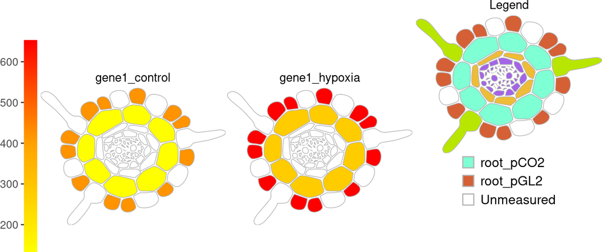

Figure 33: SHMs created with a `SummarizedExperiment` object  
Spatial features having common identifiers between the assay data and aSVG are colored.

```r
dat <- SPHM(svg=svg.root, bulk=se.aggr)
shm(data=dat, sam.factor='spFeature', con.factor='variable', ID=c("gene1"), legend.nrow=4, bar.width=0.1, legend.r=1, h=0.7)
```

# 7 Supplement

## 7.1 Troubleshooting

If errors occur when plotting SHMs, the following suggestions may be helpful:

1. Make sure that spatial feature groups do not contain nested groups.
2. SVGs are XML-like files (as shown in Figure 30B). Ensure that the SVG elements used are limited to “g,” “path,” “rect,” “ellipse,” “use,” and “title.” Using other elements could result in errors or warnings when utilizing *spatialHeatmap*. Note that “use” elements are not permitted within “g” elements.
3. Carefully review the formatting conventions for both SVGs and assay data to ensure compliance.

## 7.2 Coverting SHM SVGs to EBI SVGs

*spatialHeatmap* also works with EBI SVGs that are used in [Expression Atlas Anatomogram](https://github.com/ebi-gene-expression-group/anatomogram/tree/master/src/svg). This section illustrates the conversion of SHM SVGs to EBI SVGs.

### 7.2.1 SVG Attributes

Download the EBI SVG template EBI_template.svg (Figure 34A) and open it in Inkscape (Figure 34B). The template contains 2 layers “LAYER_OUTLINE” and “LAYER_EFO” (Figure 34C). The former is expected to store outline shapes that encircle all spatial feature shapes while the latter to store shapes of individual spatial features. As a template, both layers are empty (Figure 34B) except that “LAYER_OUTLINE” contains a green icon that links to [Expression Atlas Licence](https://www.ebi.ac.uk/gxa/licence.html).

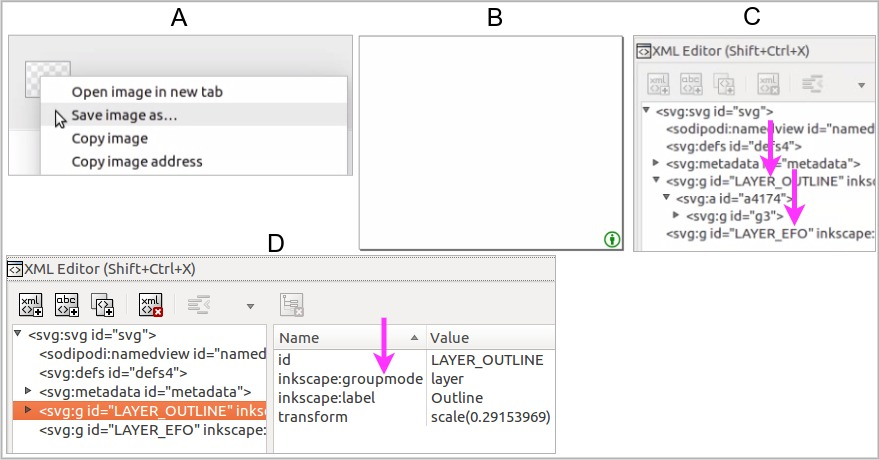

Figure 34: EBI SVG template

Note, in the EBI format, the “LAYER_OUTLINE” and “LAYER_EFO” elements start with “svg:g”, but they are actually layers, which is indicated by the “groupmode” attribute with the “layer” value (Figure 34D).

Copy “height”, “width”, “viewBox” values in the top “<svg …>” element from arabidopsis.thaliana_root.cross_shm.svg (Figure 35A) to “EBI_template.svg” (Figure 35B).

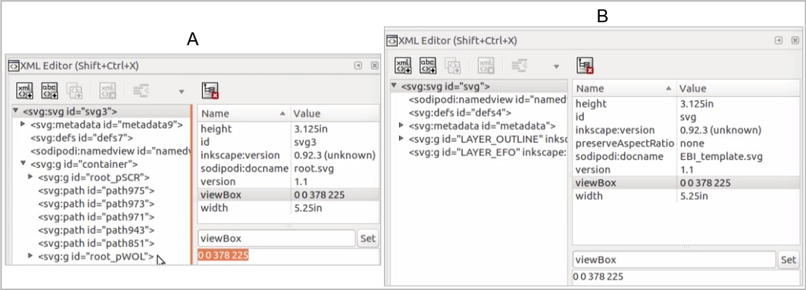

Figure 35: Copying SVG attributes

If the green icon is shrunk, it can be resized. First, select it (Figure 36A), then click the lock on the top toolbar (Figure 36B), which maintains the aspect ratio. Next, increase the height (H) or width (W). Move the icon to the bottom left corner.

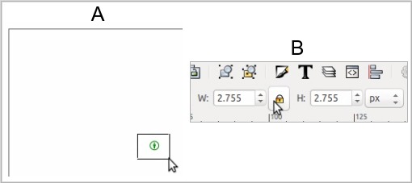

Figure 36: Resizing the green icon

### 7.2.2 Copying Spatial Features

Open arabidopsis.thaliana_root.cross_shm.svg in Inkscape, ungroup (Ctrl+Shift+G) the overall group (Figure 37), then select and copy all shapes.

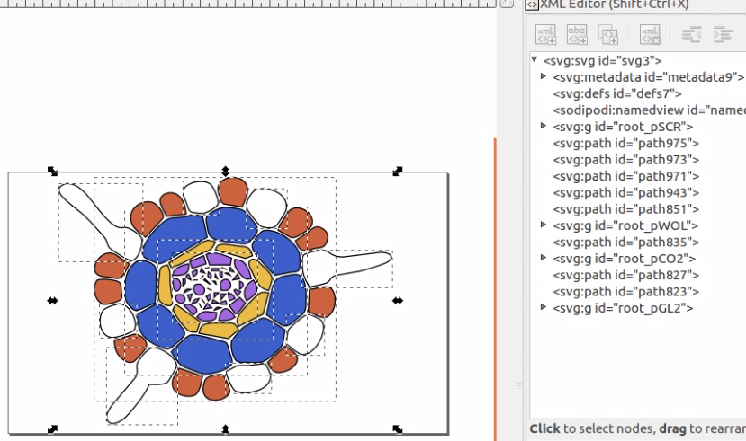

Figure 37: Ungrouping the overall group

In “EBI_template.svg”, open layer panel (Ctrl+Shift+L) and make sure the “unlock” icon is present in front of “EFO” and “Outline” (Figure 38A). Click the “EFO” layer and paste all shapes into the “EFO” layer (Figure 38A-C).

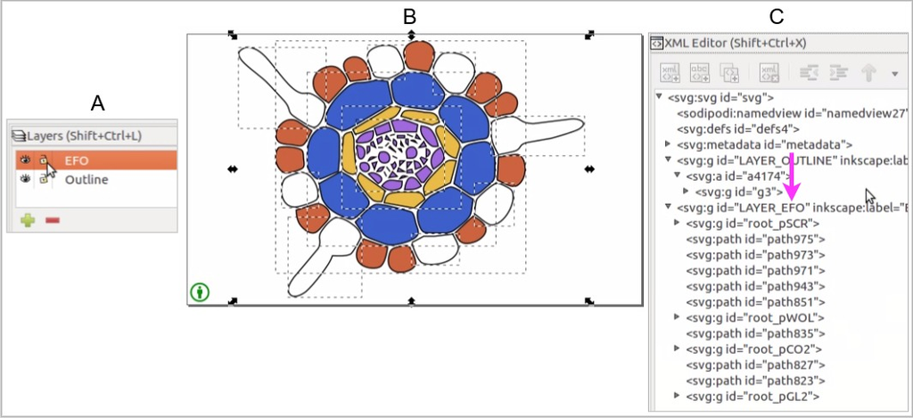

Figure 38: Pasting shapes into the EBI template

### 7.2.3 Annotating Spatial Features

In EBI SVGs, spatial features are annotated with unique identifiers and optional ontology ids. Take the “root_pSCR” (root endodermis) feature for example. Click the shape in “XML Editor” (Figure 39A), then click “New element node” on the top (Figure 39B). Type in “svg:title” and click “Create” (Figure 39C). Then a “title” node is created at the bottom of “root_pSCR”.

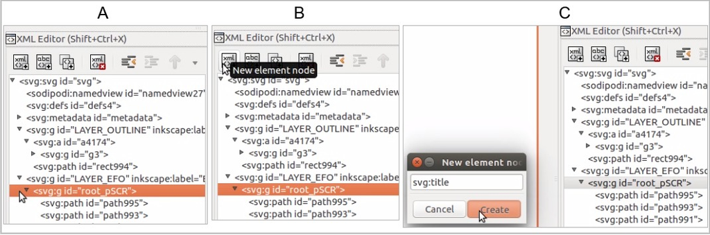

Figure 39: Creating title elements

Click the “title” node and click “New text node” at the top (Figure 40A). Then an empty text node is created inside the “title” node (Figure 40B). Click the text node and type in “root_pSCR” on the right (Figure 40C).

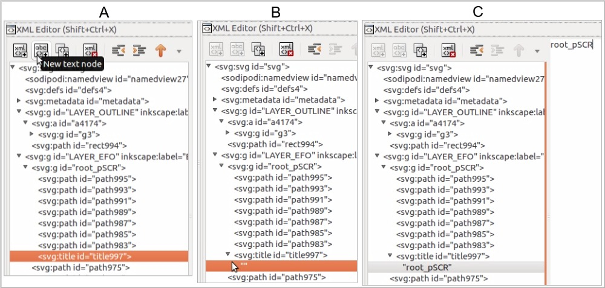

Figure 40: Adding text to text elements

Set title id as “root_pSCR” (Figure 41), then the title is done.

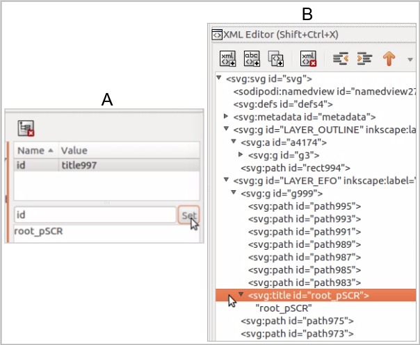

Figure 41: Adding ids to text elements

[figure not shown]

Figure 42: Adding ontology ids

### 7.2.4 Outline Shapes

The “LAYER_OUTLINE” layer is used to store the optional outline shapes. For illustration purpose, a root outline is created.

Click “Outline in the layer panel (Figure 43A), and draw an outline as explained above (Figure 43B-C).

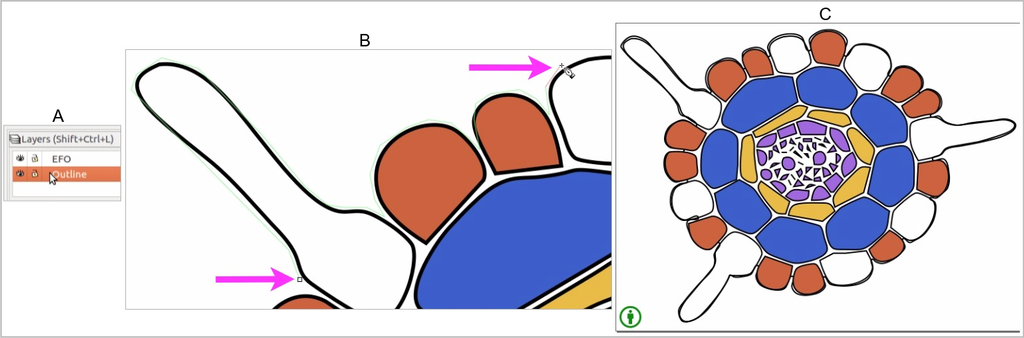

Figure 43: Creating outline shapes

Make sure all paths have absolute coordinates as shown in Section Absolute Path Position.

### 7.2.5 Resizing Canvas

Next, resize the canvas as shown in the Section Resizing Canvas.

### 7.2.6 Transparency

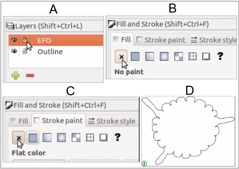

Figure 44: Setting all shapes transparent

### 7.2.7 Naming Scheme

According to the [naming scheme](https://github.com/ebi-gene-expression-group/anatomogram/tree/master/src/svg) of EBI SVGs, the aSVG is named arabidopsis_thaliana.root_cross.svg, which is ready to use for plotting SHMs.

# Reference

Morgan, Martin, Valerie Obenchain, Jim Hester, and Hervé Pagès. 2018. *SummarizedExperiment: SummarizedExperiment Container*.

Mustroph, Angelika, M Eugenia Zanetti, Charles J H Jang, Hans E Holtan, Peter P Repetti, David W Galbraith, Thomas Girke, and Julia Bailey-Serres. 2009. “Profiling Translatomes of Discrete Cell Populations Resolves Altered Cellular Priorities During Hypoxia in Arabidopsis.” *Proc Natl Acad Sci U S A* 106 (44): 18843–48.